# Problem Set 1

## — b —

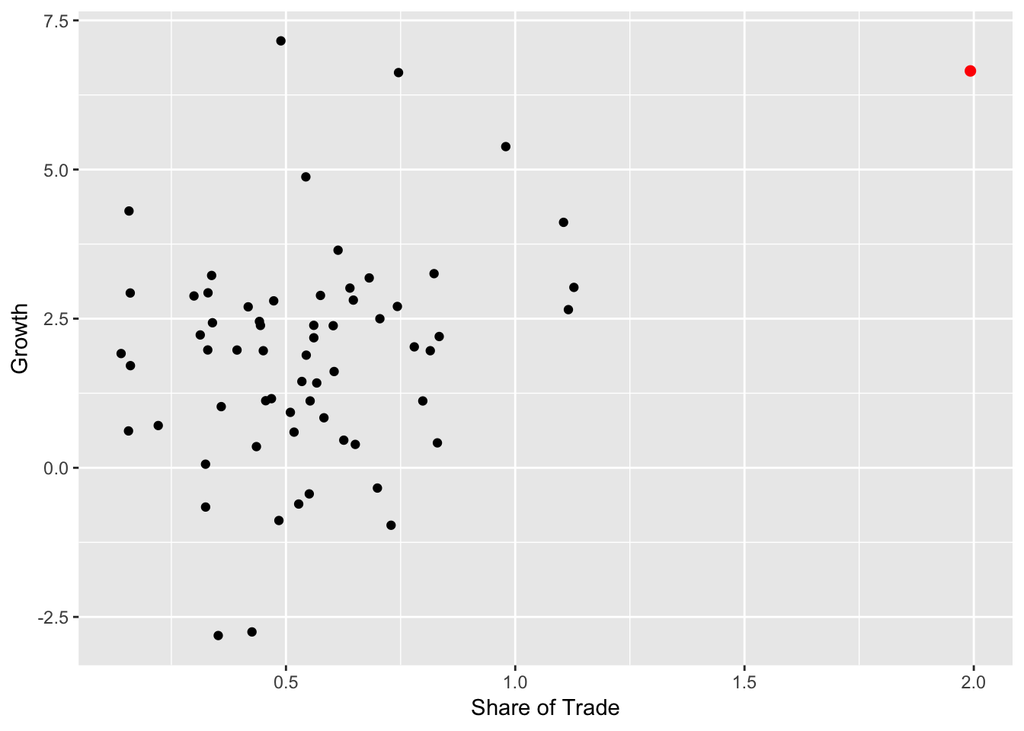

```r
plot_withMarlainred <- ggplot(growth, aes( x = tradeshare, y = growth)) + geom_point() + geom_point(data=growth[growth$country_name == "Malta",],color="red",size=2) + labs(x = "Share of Trade", y = "Growth")
plot_withMarlainred # display plot
```

Malta is the red point on the scatter plot on the upper right coner of the graph. It look like an outlier because it’s far distant from the other data (black points in graph).

## — c —

```r
reg <- lm(growth$growth ~ growth$tradeshare)
names(reg$coefficients) <- c("(Intercept)", "slope")
print("Regression Summary");
```

```
## [1] "Regression Summary"
```

```r
summary(reg)
```

```
##
## Call:
## lm(formula = growth$growth ~ growth$tradeshare)
##
## Residuals:
##     Min      1Q  Median      3Q     Max
## -4.3739 -0.8864  0.2329  0.9248  5.3889
##
## Coefficients:
##             Estimate Std. Error t value Pr(>|t|)
## (Intercept)   0.6403     0.4900   1.307  0.19606
## slope         2.3064     0.7735   2.982  0.00407 **
## ---
## Signif. codes:  0 '***' 0.001 '**' 0.01 '*' 0.05 '.' 0.1 ' ' 1
##
## Residual standard error: 1.79 on 63 degrees of freedom
## Multiple R-squared:  0.1237, Adjusted R-squared:  0.1098
## F-statistic: 8.892 on 1 and 63 DF,  p-value: 0.00407
```

```r
0.64 + 2.306*0.5
```

```
## [1] 1.793
```

```r
0.64 + 2.306*1
```

```
## [1] 2.946
```

The estimated slope is 2.306, and the estimated intercept is 0.64. When trade share is 0.5, the predicted growth rate for a country is 1.79. When trade share is 1, the predicted growth rate for a country is 2.95.

## — d —

```r
growth_new <- growth[!growth$country_name == "Malta",]
reg_withoutMalta <- lm(growth_new$growth ~ growth_new$tradeshare)
names(reg_withoutMalta$coefficients) <- c("(Intercept)", "slope")
print("Regression Summary");
```

```
## [1] "Regression Summary"
```

```r
summary(reg_withoutMalta)
```

```
##
## Call:
## lm(formula = growth_new$growth ~ growth_new$tradeshare)
##
## Residuals:
##     Min      1Q  Median      3Q     Max
## -4.4247 -0.9383  0.2091  0.9265  5.3776
##
## Coefficients:
##             Estimate Std. Error t value Pr(>|t|)
## (Intercept)   0.9574     0.5804   1.650   0.1041
## slope         1.6809     0.9874   1.702   0.0937 .
## ---
## Signif. codes:  0 '***' 0.001 '**' 0.01 '*' 0.05 '.' 0.1 ' ' 1
##
## Residual standard error: 1.789 on 62 degrees of freedom
## Multiple R-squared:  0.04466,    Adjusted R-squared:  0.02925
## F-statistic: 2.898 on 1 and 62 DF,  p-value: 0.09369
```

```r
0.957 + 1.681*0.5
```

```
## [1] 1.7975
```

```r
0.957 + 1.681*1
```

```
## [1] 2.638
```

## — e —

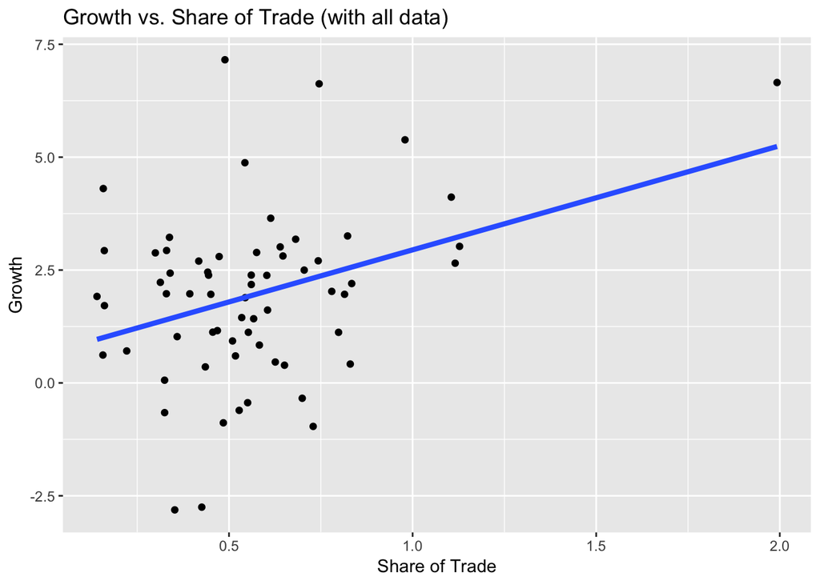

```r
plot_withregression <- plot + stat_smooth(method = "lm", fullrange = TRUE, size = 1.5, level=0)
plot_withregression + labs(title = "Growth vs. Share of Trade (with all data)")
```

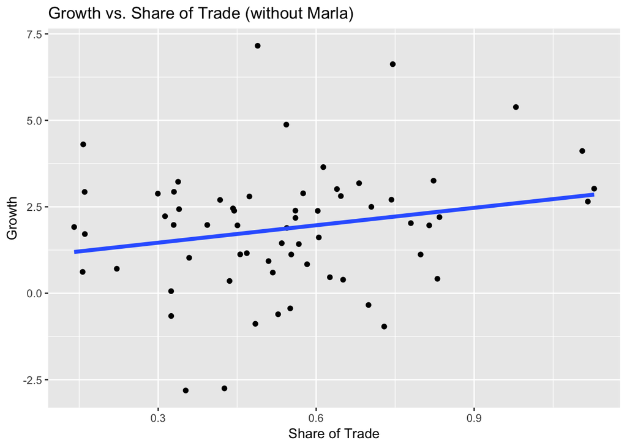

```r
plot_withregression_withoutMarla <- ggplot(growth_new, aes(x = tradeshare, y = growth)) + geom_point()+ stat_smooth(method = "lm", fullrange = TRUE, size = 1.5, level=0) + labs(title = "Growth vs. Share of Trade (without Marla)" , x = "Share of Trade", y = "Growth")
plot_withregression_withoutMarla
```

The regression function that includes Malta is steeper than the regression function that excludes Malta, because the tradesare value for Malta is extremely high. This outlier wil drive up the slop of regression.

## — f —

Malta is an island in the central Mediterranean between Sicily and the North African coast. The island a freight trans-shipment point. As a result, there are large amount of goods get shipped to Malta and get shipped out of Malta, leading to higher total number of import and export. In turn, the high sum of impot and export leads to large value of trade share. As an outlier, it should be excluded from the analysis.